# Data analysis covering the CO<sub>2</sub> emissions of passenger cars in 2018 in Europe

## Questions related to business or real-world applications

- Which vehicle characteristics show a significant influence on the vehicles CO<sub>2</sub> emission?
- How can OEMs (car manufacturers) reduce their fleet emissions?
- When is the best time to buy an electrified vehicle in europe?

The dataset analysed in this study can be downloaded [here](https://www.eea.europa.eu/data-and-maps/data/co2-cars-emission-16).  
**BEWARE: The file size exceeds 2.8 GB!!**  
In this study we will focus on the year 2018 since this is the most recent complete data collection ("Monitoring of CO2 emissions from passenger cars - Data 2018 - Provisional data"). Additional information on this page read:

> Since 2010 the EEA is collecting data from passenger cars registered in all EU Member States. The scheduling for the monitoring is the following:
> - Member States shall record information for each new passenger car and van registered in its territory and transmit this information to the Commission by 28 February of each year. Data are submitted to the Central Data Repository managed by the EEA (http://cdr.eionet.europa.eu/)
> - The EEA performs several quality checks in order to evaluate the accuracy and the quality of the dataset. On the basis of the checks and the feedbacks from Member States the EEA finalises and publishes the preliminary database. At the same time, notification letters are sent to manufacturers informing them of their provisional CO2 performances.
> - Manufacturers can, within three months of being notified of the provisional calculation, notify the Commission of any errors in the data.
> - The EEA and the European Commission assess the manufacturers’ corrections, and, where justified, take them into account for the calculation of the manufacturer final average CO2 emissions and specific emission targets. The final data and targets are to be published by 31 October each year.

> The data are required for the calculation by the Commission of the average specific emissions of CO2 from new passenger cars and for setting the specific emissions targets that shall be met by car manufacturers. The database provides the detailed data without taking into account other factors required for the calculation of specific emissions targets, such as phase-in percentages, credits for low emitting vehicles and E85 fuelled vehicles, or eco-innovation credits. In order to calculate the average specific emissions and specific emission targets the Commission considers only those vehicles for which emission and mass are available.

## Table of column definitions:

Significant columns are marked "bold + italic"!

| Field name | Field Definition | Data type | Primary key |
| --- | --- | --- | --- |
| *ID* | Identification number | integer | Yes |
| *MS* | Member state | varchar(2) | No |
| *Mp* | Manufacturer pooling | varchar(50) | No |
| VFN | Vehicle family identification number | varchar(25) | No |
| Mh | Manufacturer name | varchar(50) | No |
| Man | Manufacturer name OEM declaration | varchar(50) | No |
| MMS | Manufacturer name | varchar(125) | No |
| TAN | Type approval number | varchar(50) | No |
| T | Type | varchar(25) | No |
| Va | Variant | varchar(25) | No |
| Ve | Version | varchar(35) | No |
| Mk | Make | varchar(25) | No |
| *Cn* | Commercial name | varchar(50) | No |
| Ct | Category of the vehicle type approved | varchar(5) | No |
| Cr | Category of the vehicle registered | varchar(5) | No |
| *m (kg)* | Mass in running order | integer | No |
| *Mt* | WLTP test mass | integer | No |
| Enedc (g/km) | Specific CO2 Emissions (NEDC) | integer | No |
| *Ewltp (g/km)* | Specific CO2 Emissions (WLTP) | integer | No |
| *W (mm)* | Wheel Base | integer | No |
| *At1 (mm)* | Axle width steering axle | integer | No |
| *At2 (mm)* | Axle width other axle | integer | No |
| *Ft* | Fuel type | varchar(25) | No |
| *Fm* | Fuel mode | varchar(1) | No |
| *ec (cm3)* | Engine capacity | integer | No |
| *ep (KW)* | Engine power | integer | No |
| *z (Wh/km)* | Electric energy consumption | integer | No |
| IT | Innovative technology or group of innovative technologies | varchar(25) | No |
| Ernedc (g/km) | Emissions reduction through innovative technologies | float | No |
| Erwltp (g/km) | Emissions reduction through innovative technologies (WLTP) | float | No |
| De | Deviation factor | float | No |
| Vf | Verification factor | integer | No |
| r | Total new registrations | integer | No |

```python
# import modules and set environment
import pandas as pd
import matplotlib.pyplot as plt
import seaborn as sb
import numpy as np
pd.set_option('display.max_rows', 500)
pd.set_option('display.max_columns', 500)
pd.set_option('display.width', 1000)
%matplotlib inline
```

```python
# define helper functions

def GroupAggCount(df, group, agg_dict, counter_channel, counterchannelname = 'occurances', sort_chan_position = 0):
    '''
    INPUT:
    df - pandas dataframe
    group - columns to be grouped by
    agg_dict - dictionary to connect columns to aggregation functions like mean,
                sum or mode (lambda x:x.value_counts().index[0])
    counter_channel - which column should be counted (use a column name not used before)?
    counterchannelname - whats the name of the count-column?
    sort_chan_position - sort by this column name

    OUTPUT:
    df - a grouped dataframe using defined aggregation methods and a count column
    '''
    agg_dict[counter_channel] = 'size'
    keys = list(agg_dict.keys())
    values = list(agg_dict.values())
    rename_dict = {}
    for i in range(len(agg_dict) - 1):
        rename_dict[keys[i]] = (str(values[i]) + '(' + keys[i] + ')')
    rename_dict[counter_channel] = counterchannelname
    if (sort_chan_position) == (len(values) - 1):
        sortVar = counterchannelname
    else:
        sortVar = str(values[sort_chan_position]) + '(' + keys[sort_chan_position] + ')'
    return df.groupby(group).agg(agg_dict).rename(columns=rename_dict).sort_values(by = sortVar, ascending = True)

def mostFrequentOccurencesOf(df, column, howMany):
    '''
    INPUT:
    df - pandas dataframe
    column - column to count the occurances
    howMany - how many of the most frequent occurences should be used

    OUTPUT:
    df - a dataframe without the least frequent occuring elements
    '''
    return df[df[column].isin(df.groupby(column)[column].count().sort_values(ascending = False).index[0:howMany])]

def analyseStringTypeStatistics(df):
    '''
    INPUT:
    df - pandas dataframe

    Prints out all object typed columns with percentual occurences of unique elements
    '''
    df = df.select_dtypes(include=['object'])
    for i, v in enumerate(df.columns):
        print(df[v].value_counts() / df.shape[0])
        print('\n\n')
    return None

def create_dummy_df(df, cat_cols, dummy_na = False, drop_first = True):
    '''
    INPUT:
    df - pandas dataframe with categorical variables you want to dummy
    cat_cols - list of strings that are associated with names of the categorical columns
    dummy_na - Bool holding whether you want to dummy NA vals of categorical columns or not

    OUTPUT:
    df - a new dataframe that has the following characteristics:
            1. contains all columns that were not specified as categorical
            2. removes all the original columns in cat_cols
            3. dummy columns for each of the categorical columns in cat_cols
            4. if dummy_na is True - it also contains dummy columns for the NaN values
            5. Use a prefix of the column name with an underscore (_) for separating
    '''
    for col in  cat_cols:
        try:
            # for each cat add dummy var, drop original column
            df = pd.concat([df.drop(col, axis = 1), pd.get_dummies(df[col], prefix = col, prefix_sep = '_', drop_first = drop_first, dummy_na = dummy_na)], axis=1)
        except:
            continue

    return df

def clean_fit_linear_mod(df, response_col, cat_cols, dummy_na, test_size = .3, rand_state = 42):
    '''
    INPUT:
    df - a dataframe holding all the variables of interest
    response_col - a string holding the name of the column
    cat_cols - list of strings that are associated with names of the categorical columns
    dummy_na - Bool holding whether you want to dummy NA vals of categorical columns or not
    test_size - a float between [0,1] about what proportion of data should be in the test dataset
    rand_state - an int that is provided as the random state for splitting the data into training and test

    OUTPUT:
    test_score - float - r2 score on the test data
    train_score - float - r2 score on the test data
    lm_model - model object from sklearn
    X_train, X_test, y_train, y_test - output from sklearn train test split used for optimal model

    1. Drop the rows with missing response values
    2. Drop columns with NaN for all the values
    3. Use create_dummy_df to dummy categorical columns
    4. Fill the mean of the column for any missing values
    5. Split your data into an X matrix and a response vector y
    6. Create training and test sets of data
    7. Instantiate a LinearRegression model with normalized data
    8. Fit your model to the training data
    9. Predict the response for the training data and the test data
    10. Obtain an rsquared value for both the training and test data
    '''
    from sklearn.linear_model import LinearRegression
    from sklearn.model_selection import train_test_split
    from sklearn.metrics import r2_score

    #Drop the rows with missing response values
    df  = df.dropna(subset = [response_col], axis = 0)

    #Drop columns with all NaN values
    df = df.dropna(how = 'all', axis = 1)

    #Dummy categorical variables
    df = create_dummy_df(df, cat_cols, dummy_na) # see function in "dummy" chapter

    # Mean function
    fill_mean = lambda col: col.fillna(col.mean())
    # Fill the mean
    df = df.apply(fill_mean, axis = 0)

    #Split into explanatory and response variables
    X = df.drop(response_col, axis = 1)
    y = df[response_col]

    #Split into train and test
    X_train, X_test, y_train, y_test = train_test_split(X, y, test_size = test_size, random_state = rand_state)

    lm_model = LinearRegression(normalize = True) # Instantiate
    lm_model.fit(X_train, y_train) #Fit

    #Predict using your model
    y_test_preds = lm_model.predict(X_test)
    y_train_preds = lm_model.predict(X_train)

    #Score using your model
    test_score = r2_score(y_test, y_test_preds)
    train_score = r2_score(y_train, y_train_preds)

    coefCorr = {}
    for i, v in enumerate(X_train.columns):
        coefCorr[v] = lm_model.coef_[i]
    coefCorr = sorted(coefCorr.items(), key=lambda kv: kv[1])

    return test_score, train_score, lm_model, X_train, X_test, y_train, y_test, coefCorr

def heatMap(df, catVarNameList2D, valueName, kind = 'mean'):
    '''
    INPUT:
    df - pandas dataframe
    catVarNameList2D - list with names of the two categorical columns in focus
    valueName - name of the numeric column
    kind - how to aggregate the numeric values (mean, sum, count, percentage)
    '''
    if (kind == 'sum'):
        cat = df.groupby(catVarNameList2D).sum()[valueName]
        cat = cat.reset_index(name = 'sum(' + valueName + ')')
        cat = cat.pivot(index = catVarNameList2D[1], columns = catVarNameList2D[0],
                                    values = 'sum(' + valueName + ')')
        sb.heatmap(cat, annot = True, fmt = '.3f',
                   cbar_kws = {'label' : 'sum(' + valueName + ')'})
    elif (kind == 'count'):
        cat = df.groupby(catVarNameList2D).count()[valueName]
        cat = cat.reset_index(name = 'count(' + valueName + ')')
        cat = cat.pivot(index = catVarNameList2D[1], columns = catVarNameList2D[0],
                                    values = 'count(' + valueName + ')')
        sb.heatmap(cat, annot = True, fmt = '.0f',
                   cbar_kws = {'label' : 'occurances of combinations'})
    elif (kind == 'percentage'):
        cat = df.groupby(catVarNameList2D).count()[valueName]
        cat = cat.reset_index(name = 'count(' + valueName + ')')
        cat['count(' + valueName + ')'] = cat['count(' + valueName + ')'] / cat['count(' + valueName + ')'].sum() * 100
        cat = cat.pivot(index = catVarNameList2D[1], columns = catVarNameList2D[0],
                                    values = 'count(' + valueName + ')')
        sb.heatmap(cat, annot = True, fmt = '.2f',
                   cbar_kws = {'label' : 'occurances of combinations'})
    else:
        cat = df.groupby(catVarNameList2D).mean()[valueName]
        cat = cat.reset_index(name = 'mean(' + valueName + ')')
        cat = cat.pivot(index = catVarNameList2D[1], columns = catVarNameList2D[0],
                                    values = 'mean(' + valueName + ')')
        sb.heatmap(cat, annot = True, fmt = '.3f',
                   cbar_kws = {'label' : 'mean(' + valueName + ')'})
    return None

def reducedQuadrHeatMap(df, catVarNameList2D, valueName, cutOff, kind = 'mean'):
    '''
    INPUT:
    df - pandas dataframe
    catVarNameList2D - list with names of the two categorical columns in focus
    valueName - name of the numeric column
    cutOff - how many of the most frequent categories should be included
    kind - how to aggregate the numeric values (mean, sum, count, percentage)
    '''
    heatMap(mostFrequentOccurencesOf(mostFrequentOccurencesOf(df, catVarNameList2D[1], cutOff), catVarNameList2D[0], cutOff), catVarNameList2D, valueName, kind)
    return None

def mean_poly(x, y, bins = 10, **kwargs):
    '''
    function for dicretized FacetGrid line plot. EXAMPLE:
    g = sb.FacetGrid(data = mostFrequentOccurencesOf(df, 'Mp', 9), hue ='Mp', height = 8)
    g.map(mean_poly, 'ep (KW)', 'Ewltp (g/km)', bins = 5)
    g.set_ylabels('mean(Ewltp (g/km))')
    g.set(xlim = (50,200))
    g.add_legend()

    INPUT:
    x - x axes values (pandas series)
    y - y axes values (pandas series)
    bins - number of value ranges for the seperation of the continuous variable
    '''
    # set bin edges if none or int specified
    if type(bins) == int:
        bins = np.linspace(x.min(), x.max(), bins + 1)
    bin_centers = (bins[1:] + bins[:-1]) / 2# compute counts
    data_bins = pd.cut(x, bins, right = False, include_lowest = True)
    means = y.groupby(data_bins).mean()
    sems = y.groupby(data_bins).sem()

    # create plot
    plt.errorbar(x = bin_centers, y = means.values, yerr = sems.values, **kwargs)
```

## Importing / Gathering

```python
# read csv file / drop bad rows
df = pd.read_csv('./Monitoring of CO2 emissions from new passenger cars registered in 2018 across EU-28 Regulation (EC) No 4432009.csv', error_bad_lines = False)#, nrows = 5000)
```

```
b'Skipping line 4923864: expected 33 fields, saw 34\n'
```

```python
# show initial data structure
df.head()
```

|  | ID | MS | VFN | Mp | Mh | Man | MMS | Tan | T | Va | Ve | Mk | Cn | Ct | Cr | r | m (kg) | Mt | Enedc (g/km) | Ewltp (g/km) | W (mm) | At1 (mm) | At2 (mm) | Ft | Fm | ec (cm3) | ep (KW) | z (Wh/km) | IT | … |
| --- | --- | --- | --- | --- | --- | --- | --- | --- | --- | --- | --- | --- | --- | --- | --- | --- | --- | --- | --- | --- | --- | --- | --- | --- | --- | --- | --- | --- | --- | --- |
| 0 | 1314992 | FR | NaN | RENAULT | RENAULT | RENAULT SAS | RENAULT SAS | e2*2007/46*0574*05 | RFA | RF2 | NCBRVA015000 | RENAULT | SCENIC | M1 | M1 | 1 | 1565.0 | NaN | 124.0 | NaN | 2804.0 | 1602 | 1602 | Petrol | M | 1332.0 | 120.0 | NaN | NaN | … |
| 1 | 1314994 | FR | NaN | RENAULT | RENAULT | RENAULT SAS | RENAULT SAS | e2*2007/46*0574*05 | RFA | JF2 | NCBRVA015000 | RENAULT | SCENIC | M1 | M1 | 1 | 1505.0 | NaN | 122.0 | NaN | 2734.0 | 1602 | 1602 | Petrol | M | 1332.0 | 120.0 | NaN | NaN | … |
| 2 | 1314995 | FR | NaN | RENAULT | RENAULT | RENAULT SAS | RENAULT SAS | e2*2007/46*0574*05 | RFA | RF2 | N96RVA017000 | RENAULT | SCENIC | M1 | M1 | 1 | 1556.0 | NaN | 125.0 | NaN | 2804.0 | 1602 | 1602 | Petrol | M | 1332.0 | 85.0 | NaN | NaN | … |
| 3 | 1314996 | FR | NaN | RENAULT | RENAULT | RENAULT SAS | RENAULT SAS | e2*2007/46*0574*05 | RFA | RH2 | A36RVA017000 | RENAULT | SCENIC | M1 | M1 | 1 | 1607.0 | NaN | 104.0 | NaN | 2804.0 | 1602 | 1602 | Diesel | M | 1461.0 | 81.0 | NaN | NaN | … |
| 4 | 1315003 | FR | NaN | RENAULT | RENAULT | RENAULT SAS | RENAULT SAS | e2*2007/46*0574*05 | RFA | RH2 | A36RVA017000 | RENAULT | SCENIC | M1 | M1 | 1 | 1607.0 | NaN | 104.0 | NaN | 2804.0 | 1602 | 1602 | Diesel | M | 1461.0 | 81.0 | NaN | NaN | … |

## Cleaning

```python
# drop irrelevant data colums and columns with "NaNs" within response variables (CO2 emissions) to reduce calculation time from here on
df.dropna(subset = ['Enedc (g/km)', 'Ewltp (g/km)'], inplace = True)
df.drop(['VFN', 'Mh','Man', 'MMS', 'Tan', 'T', 'Va', 'Ve', 'Mk', 'Ct', 'Cr', 'IT', 'De', 'Vf', 'r', 'Ernedc (g/km)', 'Erwltp (g/km)', 'Enedc (g/km)'], axis=1, inplace=True)
```

```python
# correct dtype conversion
df['At1 (mm)'] = pd.to_numeric(df['At1 (mm)'], errors = 'coerce')
df['At2 (mm)'] = pd.to_numeric(df['At1 (mm)'], errors = 'coerce')
```

```python
# convert all strings to lower case to avoid redundant categories
for i, v in enumerate(df.select_dtypes(include=['object']).columns):
    df[v] = df[v].str.lower()
```

```python
# create 'simple_Cn' column to reduce car name variance
df['simple_Cn'] = df['Cn'].str.split(' ').str[0]
```

```python
# create engine power specific CO2 emissions
df['RelEwltp (g/km/KW)'] = df['Ewltp (g/km)'] / df['ep (KW)']
```

```python
# correct single data errors
df = df.drop(df[df['Ft'] == '1598'].index)
df = df.drop(df[df['Ft'] == 'm'].index)
df = df.drop(df[df['Ft'] == 'ng-biomethane'].index)
```

```python
# show cleaning results
df.head()
```

|  | ID | MS | Mp | Cn | m (kg) | Mt | Ewltp (g/km) | W (mm) | At1 (mm) | At2 (mm) | Ft | Fm | ec (cm3) | ep (KW) | z (Wh/km) | simple_Cn | RelEwltp (g/km/KW) |
| --- | --- | --- | --- | --- | --- | --- | --- | --- | --- | --- | --- | --- | --- | --- | --- | --- | --- |
| 103 | 445296 | fi | ford-werke gmbh | s-max | 1905.0 | 2107.0 | 173.0 | 2850.0 | 1606.0 | 1606.0 | diesel | m | 1995.0 | 110.0 | NaN | s-max | 1.572727 |
| 107 | 307893 | sk | vw group pc | octavia | 1370.0 | NaN | 131.0 | 2667.0 | 1533.0 | 1533.0 | diesel | m | 1598.0 | 85.0 | NaN | octavia | 1.541176 |
| 117 | 307942 | sk | vw group pc | octavia | 1370.0 | NaN | 131.0 | 2667.0 | 1533.0 | 1533.0 | diesel | m | 1598.0 | 85.0 | NaN | octavia | 1.541176 |
| 118 | 307945 | sk | vw group pc | octavia | 1370.0 | NaN | 130.0 | 2667.0 | 1533.0 | 1533.0 | diesel | m | 1598.0 | 85.0 | NaN | octavia | 1.529412 |
| 119 | 307947 | sk | vw group pc | octavia | 1385.0 | NaN | 139.0 | 2667.0 | 1533.0 | 1533.0 | diesel | m | 1598.0 | 85.0 | NaN | octavia | 1.635294 |

```python
# show cleaning results
df.info()
```

```
<class 'pandas.core.frame.DataFrame'>
Int64Index: 4090461 entries, 103 to 15272908
Data columns (total 17 columns):
ID                    int64
MS                    object
Mp                    object
Cn                    object
m (kg)                float64
Mt                    float64
Ewltp (g/km)          float64
W (mm)                float64
At1 (mm)              float64
At2 (mm)              float64
Ft                    object
Fm                    object
ec (cm3)              float64
ep (KW)               float64
z (Wh/km)             float64
simple_Cn             object
RelEwltp (g/km/KW)    float64
dtypes: float64(10), int64(1), object(6)
memory usage: 561.7+ MB
```

```python
# show cleaning results
df.describe()
```

|  | ID | m (kg) | Mt | Ewltp (g/km) | W (mm) | At1 (mm) | At2 (mm) | ec (cm3) | ep (KW) | z (Wh/km) | RelEwltp (g/km/KW) |
| --- | --- | --- | --- | --- | --- | --- | --- | --- | --- | --- | --- |
| count | 4.090461e+06 | 4.090437e+06 | 3.940558e+06 | 4.090461e+06 | 4.086894e+06 | 4.086888e+06 | 4.086888e+06 | 4.010582e+06 | 3.271538e+06 | 100986.000000 | 3.271538e+06 |
| mean | 6.934549e+06 | 1.393419e+03 | 1.529831e+03 | 1.470477e+02 | 2.637842e+03 | 1.538042e+03 | 1.538042e+03 | 1.530157e+03 | 9.440733e+01 | 161.079348 | 1.702147e+00 |
| std | 4.364126e+06 | 2.891530e+02 | 3.080966e+02 | 3.482155e+01 | 1.713557e+02 | 6.081341e+01 | 6.081341e+01 | 4.918084e+02 | 4.125162e+01 | 31.868833 | 5.312720e-01 |
| min | 8.020000e+02 | 2.050000e+02 | 1.000000e+00 | 0.000000e+00 | 1.867000e+03 | 1.016000e+03 | 1.016000e+03 | 6.000000e+02 | 1.800000e+01 | 24.000000 | 0.000000e+00 |
| 25% | 3.216657e+06 | 1.164000e+03 | 1.291000e+03 | 1.320000e+02 | 2.539000e+03 | 1.499000e+03 | 1.499000e+03 | 1.199000e+03 | 6.600000e+01 | 134.000000 | 1.381818e+00 |
| 50% | 6.104727e+06 | 1.375000e+03 | 1.496000e+03 | 1.450000e+02 | 2.634000e+03 | 1.541000e+03 | 1.541000e+03 | 1.498000e+03 | 8.500000e+01 | 158.000000 | 1.647059e+00 |
| 75% | 1.034174e+07 | 1.575000e+03 | 1.721000e+03 | 1.630000e+02 | 2.700000e+03 | 1.576000e+03 | 1.576000e+03 | 1.956000e+03 | 1.100000e+02 | 186.000000 | 2.060000e+00 |
| max | 1.527276e+07 | 3.087000e+03 | 5.144000e+03 | 4.990000e+02 | 3.840000e+03 | 2.807000e+03 | 2.807000e+03 | 6.752000e+03 | 5.880000e+02 | 1476.000000 | 9.500000e+00 |

## Analyze

> The following block(s) might be useful to answer question(s) like:
> - How can OEMs reduce their fleet emissions?

```python
# show the accumulated CO2 emissions by OEM-group
counterchannelname = 'No_of_reported_registered_passenger_cars'
channel_dict = {'Ewltp (g/km)':'sum', 'RelEwltp (g/km/KW)':'sum'}
GroupAggCount(df, 'Mp',channel_dict , 'ID', counterchannelname, 0)
```

| Mp | sum(Ewltp (g/km)) | sum(RelEwltp (g/km/KW)) | No_of_reported_registered_passenger_cars |
| --- | --- | --- | --- |
| mitsubishi motors | 3083527.0 | 2.946157e+04 | 25174 |
| honda motor europe ltd | 4684234.0 | 2.589228e+04 | 32021 |
| suzuki pool | 5189509.0 | 5.695348e+04 | 37564 |
| tata motors jaguar land rover | 10456819.0 | 2.138004e+04 | 52360 |
| kia | 14729783.0 | 1.276186e+05 | 102505 |
| hyundai | 19422382.0 | 1.844384e+05 | 133302 |
| fca italy spa | 26709215.0 | 3.556610e+05 | 171273 |
| toyota-mazda | 47162203.0 | 5.150092e+05 | 362224 |
| daimler ag | 48937897.0 | 3.268032e+05 | 302719 |
| renault | 50056302.0 | 6.657494e+05 | 369007 |
| ford-werke gmbh | 50331732.0 | 4.124268e+05 | 327080 |
| bmw group | 69537657.0 | 4.101340e+05 | 443415 |
| vw group pc | 89819045.0 | 8.328057e+05 | 623662 |
| psa-opel | 109788291.0 | 1.161153e+06 | 765088 |

```python
# calculate the mean CO2 emissions for all OEM-groups (fleet emissions), sort by registered vehicles
channel_dict = {'ep (KW)':'mean', 'ec (cm3)':'mean', 'm (kg)':'mean', 'Ewltp (g/km)':'mean', 'RelEwltp (g/km/KW)':'mean'}
pool_fleet_emmissions = GroupAggCount(df, 'Mp',channel_dict , 'ID', counterchannelname, 5)
pool_fleet_emmissions
```

| Mp | mean(ep (KW)) | mean(ec (cm3)) | mean(m (kg)) | mean(Ewltp (g/km)) | mean(RelEwltp (g/km/KW)) | No_of_reported_registered_passenger_cars |
| --- | --- | --- | --- | --- | --- | --- |
| mitsubishi motors | 85.816646 | 1723.419234 | 1476.182371 | 122.488560 | 1.659059 | 25174 |
| honda motor europe ltd | 110.191028 | 1416.695044 | 1346.004185 | 146.286312 | 1.394457 | 32021 |
| suzuki pool | 79.562391 | 1248.453892 | 1046.073075 | 138.151129 | 1.769621 | 37564 |
| tata motors jaguar land rover | 160.871303 | 2242.271386 | 1994.172651 | 199.710065 | 1.306529 | 52360 |
| kia | 84.138845 | 1385.815396 | 1343.497927 | 143.698190 | 1.807348 | 102505 |
| hyundai | 84.920140 | 1340.139778 | 1309.417668 | 145.702105 | 1.836103 | 133302 |
| fca italy spa | 73.122323 | 1348.461865 | 1237.845446 | 155.945275 | 2.342156 | 171273 |
| daimler ag | 124.628210 | 1821.623861 | 1565.326785 | 161.661135 | 1.397090 | 302719 |
| ford-werke gmbh | 92.867206 | 1351.849148 | 1425.455204 | 153.882023 | 1.762048 | 327080 |
| toyota-mazda | 78.249247 | 1684.252502 | 1325.769297 | 130.201762 | 1.757771 | 362224 |
| renault | 68.294684 | 1164.385983 | 1237.757297 | 135.651362 | 2.000545 | 369007 |
| bmw group | 129.445573 | 1965.448416 | 1600.355036 | 156.822969 | 1.284032 | 443415 |
| vw group pc | 96.974204 | 1502.602187 | 1379.606385 | 144.018787 | 1.592527 | 623662 |
| psa-opel | 84.104653 | 1363.982303 | 1270.208389 | 143.497599 | 1.796200 | 765088 |

> The following block(s) might be useful to answer question(s) like:
> - Which vehicle characteristics show a significant influence on the vehicles CO2 emission?
> - How can OEMs reduce their fleet emissions?

```python
# calculate the mean CO2 emissions for different fuel types
channel_dict = {'ep (KW)':'mean', 'ec (cm3)':'mean', 'm (kg)':'mean', 'Ewltp (g/km)':'mean', 'RelEwltp (g/km/KW)':'mean'}
Ft_emmissions = GroupAggCount(df, 'Ft',channel_dict , 'ID', counterchannelname, 3)
Ft_emmissions
```

| Ft | mean(ep (KW)) | mean(ec (cm3)) | mean(m (kg)) | mean(Ewltp (g/km)) | mean(RelEwltp (g/km/KW)) | No_of_reported_registered_passenger_cars |
| --- | --- | --- | --- | --- | --- | --- |
| electric | 84.842003 | NaN | 1563.043798 | 0.000000 | 0.000000 | 79849 |
| hydrogen | 60.793103 | NaN | 1924.172414 | 0.000000 | 0.000000 | 29 |
| petrol/electric | 142.443681 | 1816.390846 | 1900.970299 | 61.733652 | 0.521861 | 40571 |
| diesel/electric | 133.459459 | 1966.378378 | 2011.351351 | 76.891892 | 0.557386 | 37 |
| ng | 61.551746 | 1056.886579 | 1217.085648 | 131.915749 | 2.171364 | 6445 |
| lpg | 62.751719 | 1216.012539 | 1164.652012 | 143.589975 | 2.359243 | 92509 |
| petrol | 85.867194 | 1357.898698 | 1269.689023 | 147.232399 | 1.867693 | 2489628 |
| diesel | 111.390794 | 1855.839414 | 1607.966610 | 158.074297 | 1.485399 | 1378580 |

```python
# sort by power specific CO2 emissions
Ft_emmissions.sort_values(by = 'mean(RelEwltp (g/km/KW))')
```

| Ft | mean(ep (KW)) | mean(ec (cm3)) | mean(m (kg)) | mean(Ewltp (g/km)) | mean(RelEwltp (g/km/KW)) | No_of_reported_registered_passenger_cars |
| --- | --- | --- | --- | --- | --- | --- |
| electric | 84.842003 | NaN | 1563.043798 | 0.000000 | 0.000000 | 79849 |
| hydrogen | 60.793103 | NaN | 1924.172414 | 0.000000 | 0.000000 | 29 |
| petrol/electric | 142.443681 | 1816.390846 | 1900.970299 | 61.733652 | 0.521861 | 40571 |
| diesel/electric | 133.459459 | 1966.378378 | 2011.351351 | 76.891892 | 0.557386 | 37 |
| diesel | 111.390794 | 1855.839414 | 1607.966610 | 158.074297 | 1.485399 | 1378580 |
| petrol | 85.867194 | 1357.898698 | 1269.689023 | 147.232399 | 1.867693 | 2489628 |
| ng | 61.551746 | 1056.886579 | 1217.085648 | 131.915749 | 2.171364 | 6445 |
| lpg | 62.751719 | 1216.012539 | 1164.652012 | 143.589975 | 2.359243 | 92509 |

> The following block(s) might be useful to answer question(s) like:
> - How can OEMs reduce their fleet emissions?
> - When is the best time to buy an electrified vehicle in europe?

```python
# calculate the mean CO2 emissions for country of vehicle registration
channel_dict = {'ep (KW)':'mean', 'm (kg)':'mean', 'Ft_petrol':'mean', 'Ft_diesel':'mean', 'Ft_electric':'mean', 'Ewltp (g/km)':'mean', 'RelEwltp (g/km/KW)':'mean'}
MS_emmissions = GroupAggCount(create_dummy_df(df, ['Ft'], dummy_na = False, drop_first = False), 'MS',channel_dict , 'ID', counterchannelname, 5)
MS_emmissions
```

| MS | mean(ep (KW)) | mean(m (kg)) | mean(Ft_petrol) | mean(Ft_diesel) | mean(Ft_electric) | mean(Ewltp (g/km)) | mean(RelEwltp (g/km/KW)) | No_of_reported_registered_passenger_cars |
| --- | --- | --- | --- | --- | --- | --- | --- | --- |
| pt | 91.049747 | 1405.605964 | 0.422621 | 0.509002 | 0.037435 | 133.011495 | 1.593787 | 62375 |
| gr | 75.962082 | 1226.049983 | 0.803171 | 0.185453 | 0.000000 | 136.597036 | 1.884406 | 2901 |
| fr | 83.905195 | 1310.400742 | 0.590824 | 0.383339 | 0.018607 | 138.391565 | 1.767269 | 761018 |
| dk | 91.565330 | 1333.407046 | 0.690283 | 0.292917 | 0.003990 | 138.999374 | 1.659800 | 55893 |
| fi | 100.502129 | 1466.699229 | 0.666435 | 0.257668 | 0.028297 | 139.384089 | 1.516553 | 27353 |
| at | 99.788049 | 1483.102748 | 0.494522 | 0.419865 | 0.078174 | 143.481044 | 1.539164 | 86435 |
| nl | 93.539228 | 1317.520078 | 0.862845 | 0.136764 | 0.000000 | 144.958791 | 1.677600 | 92115 |
| it | 79.952035 | 1308.708112 | 0.450743 | 0.377813 | 0.000000 | 145.014152 | 1.980677 | 556299 |
| si | 90.505862 | 1377.830603 | 0.692545 | 0.274387 | 0.029986 | 145.337818 | 1.709751 | 13306 |
| ie | 95.818691 | 1434.604363 | 0.417158 | 0.579894 | 0.000000 | 145.566627 | 1.648820 | 3392 |
| bg | 104.695652 | 1442.578696 | 0.713043 | 0.258261 | 0.017391 | 145.740435 | 1.573769 | 2300 |
| se | 125.672629 | 1609.698256 | 0.464010 | 0.417318 | 0.070257 | 145.981674 | 1.277390 | 100403 |
| es | 91.451980 | 1397.123167 | 0.681843 | 0.295410 | 0.005918 | 146.405067 | 1.689748 | 298595 |
| be | 92.697073 | 1393.711907 | 0.669062 | 0.311894 | 0.000000 | 147.545922 | 1.720752 | 91002 |
| hu | 92.693338 | 1422.881774 | 0.718504 | 0.231434 | 0.049637 | 149.450286 | 1.676036 | 25908 |
| gb | NaN | 1444.645278 | 0.667672 | 0.301178 | 0.010795 | 151.371832 | NaN | 813432 |
| de | 112.800956 | 1485.334715 | 0.579745 | 0.359539 | 0.050855 | 152.182650 | 1.507909 | 711904 |
| lv | 99.989581 | 1469.296692 | 0.646783 | 0.339411 | 0.009117 | 153.960667 | 1.637121 | 3839 |
| pl | 95.940910 | 1324.152277 | 0.749198 | 0.249982 | 0.000000 | 154.027044 | 1.727622 | 330240 |
| sk | 98.133166 | 1426.692857 | 0.681036 | 0.272556 | 0.001420 | 154.588221 | 1.695748 | 23940 |
| ee | 98.868558 | 1440.265133 | 0.712383 | 0.285368 | 0.000000 | 155.654099 | 1.664417 | 5782 |
| lt | 86.097303 | 1357.972128 | 0.787812 | 0.210989 | 0.000000 | 156.638861 | 2.041967 | 10010 |
| lu | 120.707297 | 1537.388551 | 0.460521 | 0.523421 | 0.000000 | 161.695316 | 1.472824 | 12019 |

```python
# sort by power specific CO2 emissions
MS_emmissions.sort_values(by = 'mean(RelEwltp (g/km/KW))')
```

| MS | mean(ep (KW)) | mean(m (kg)) | mean(Ft_petrol) | mean(Ft_diesel) | mean(Ft_electric) | mean(Ewltp (g/km)) | mean(RelEwltp (g/km/KW)) | No_of_reported_registered_passenger_cars |
| --- | --- | --- | --- | --- | --- | --- | --- | --- |
| se | 125.672629 | 1609.698256 | 0.464010 | 0.417318 | 0.070257 | 145.981674 | 1.277390 | 100403 |
| lu | 120.707297 | 1537.388551 | 0.460521 | 0.523421 | 0.000000 | 161.695316 | 1.472824 | 12019 |
| de | 112.800956 | 1485.334715 | 0.579745 | 0.359539 | 0.050855 | 152.182650 | 1.507909 | 711904 |
| fi | 100.502129 | 1466.699229 | 0.666435 | 0.257668 | 0.028297 | 139.384089 | 1.516553 | 27353 |
| at | 99.788049 | 1483.102748 | 0.494522 | 0.419865 | 0.078174 | 143.481044 | 1.539164 | 86435 |
| bg | 104.695652 | 1442.578696 | 0.713043 | 0.258261 | 0.017391 | 145.740435 | 1.573769 | 2300 |
| pt | 91.049747 | 1405.605964 | 0.422621 | 0.509002 | 0.037435 | 133.011495 | 1.593787 | 62375 |
| lv | 99.989581 | 1469.296692 | 0.646783 | 0.339411 | 0.009117 | 153.960667 | 1.637121 | 3839 |
| ie | 95.818691 | 1434.604363 | 0.417158 | 0.579894 | 0.000000 | 145.566627 | 1.648820 | 3392 |
| dk | 91.565330 | 1333.407046 | 0.690283 | 0.292917 | 0.003990 | 138.999374 | 1.659800 | 55893 |
| ee | 98.868558 | 1440.265133 | 0.712383 | 0.285368 | 0.000000 | 155.654099 | 1.664417 | 5782 |
| hu | 92.693338 | 1422.881774 | 0.718504 | 0.231434 | 0.049637 | 149.450286 | 1.676036 | 25908 |
| nl | 93.539228 | 1317.520078 | 0.862845 | 0.136764 | 0.000000 | 144.958791 | 1.677600 | 92115 |
| es | 91.451980 | 1397.123167 | 0.681843 | 0.295410 | 0.005918 | 146.405067 | 1.689748 | 298595 |
| sk | 98.133166 | 1426.692857 | 0.681036 | 0.272556 | 0.001420 | 154.588221 | 1.695748 | 23940 |
| si | 90.505862 | 1377.830603 | 0.692545 | 0.274387 | 0.029986 | 145.337818 | 1.709751 | 13306 |
| be | 92.697073 | 1393.711907 | 0.669062 | 0.311894 | 0.000000 | 147.545922 | 1.720752 | 91002 |
| pl | 95.940910 | 1324.152277 | 0.749198 | 0.249982 | 0.000000 | 154.027044 | 1.727622 | 330240 |
| fr | 83.905195 | 1310.400742 | 0.590824 | 0.383339 | 0.018607 | 138.391565 | 1.767269 | 761018 |
| gr | 75.962082 | 1226.049983 | 0.803171 | 0.185453 | 0.000000 | 136.597036 | 1.884406 | 2901 |
| it | 79.952035 | 1308.708112 | 0.450743 | 0.377813 | 0.000000 | 145.014152 | 1.980677 | 556299 |
| lt | 86.097303 | 1357.972128 | 0.787812 | 0.210989 | 0.000000 | 156.638861 | 2.041967 | 10010 |
| gb | NaN | 1444.645278 | 0.667672 | 0.301178 | 0.010795 | 151.371832 | NaN | 813432 |

```python
# Analyse Categories
analyseStringTypeStatistics(df)
```

```
gb    0.198861
fr    0.186047
de    0.174040
it    0.135999
pl    0.080734
es    0.072998
se    0.024546
nl    0.022519
be    0.022247
at    0.021131
pt    0.015249
dk    0.013664
fi    0.006687
hu    0.006334
sk    0.005853
si    0.003253
lu    0.002938
lt    0.002447
ee    0.001414
lv    0.000939
ie    0.000829
gr    0.000709
bg    0.000562
Name: MS, dtype: float64



psa-opel                         0.187042
vw group pc                      0.152467
bmw group                        0.108402
renault                          0.090212
toyota-mazda                     0.088553
ford-werke gmbh                  0.079962
daimler ag                       0.074006
fca italy spa                    0.041871
hyundai                          0.032589
kia                              0.025060
tata motors jaguar land rover    0.012801
suzuki pool                      0.009183
honda motor europe ltd           0.007828
```

[output cut: 37 more lines]

```



toyota      3.091876e-02
clio        2.840707e-02
fiesta      2.286759e-02
308         2.137363e-02
golf        2.123184e-02
                ...
r1ecls      2.444712e-07
ducato      2.444712e-07
316         2.444712e-07
sl500       2.444712e-07
roadster    2.444712e-07
Name: simple_Cn, Length: 833, dtype: float64
```

```python
# create list of all OEM pools sorted by no. of registered vehicles
OEMs = list(pool_fleet_emmissions.index)
OEMs
```

```
['mitsubishi motors',
 'honda motor europe ltd',
 'suzuki pool',
 'tata motors jaguar land rover',
 'kia',
 'hyundai',
 'fca italy spa',
 'daimler ag',
 'ford-werke gmbh',
 'toyota-mazda',
 'renault',
 'bmw group',
 'vw group pc',
 'psa-opel']
```

```python
# create a dictionary with all OEM-group specific CO2 emisions sorted by product name
channel_dict = {'ep (KW)':'mean', 'ec (cm3)':'mean', 'm (kg)':'mean', 'Ewltp (g/km)':'mean', 'RelEwltp (g/km/KW)':'mean'}
OEM_veh_pools = {}
for OEM in OEMs:
    OEM_veh_pools[OEM] = GroupAggCount(df[df['Mp'] == OEM], 'simple_Cn',channel_dict , 'ID', counterchannelname, 5)

# Show most registered car brands of OEM with most registrations in europe in 2018
OEM_veh_pools[OEMs[-1]].sort_values(by = counterchannelname, ascending = False)
```

| simple_Cn | mean(ep (KW)) | mean(ec (cm3)) | mean(m (kg)) | mean(Ewltp (g/km)) | mean(RelEwltp (g/km/KW)) | No_of_reported_registered_passenger_cars |
| --- | --- | --- | --- | --- | --- | --- |
| 308 | 94.449685 | 1392.165319 | 1276.070716 | 133.168472 | 1.426543 | 86572 |
| 3008 | 101.661159 | 1514.288174 | 1487.154446 | 150.555820 | 1.491009 | 84567 |
| c3 | 69.055479 | 1242.701274 | 1134.793298 | 137.093425 | 2.016909 | 82815 |
| 208 | 64.742343 | 1246.140353 | 1086.106359 | 129.991347 | 2.053023 | 71306 |
| 2008 | 78.364376 | 1279.460389 | 1226.367109 | 142.093669 | 1.853249 | 43750 |
| corsa-e | 63.200011 | 1362.977697 | 1168.615120 | 149.905002 | 2.420331 | 37843 |
| mokka | 101.776848 | 1376.097599 | 1401.760282 | 171.257514 | 1.661511 | 35400 |
| corsa | 67.785546 | 1392.417444 | 1172.110962 | 147.689542 | 2.217867 | 34958 |
| 5008 | 105.974102 | 1583.929700 | 1522.094383 | 155.178561 | 1.481232 | 31849 |
| astra | 94.209377 | 1433.460421 | 1320.565547 | 145.289378 | 1.549755 | 31115 |
| 108 | 53.000000 | 998.262348 | 919.510126 | 115.234830 | 2.172022 | 27109 |
| c1 | 52.999951 | 998.008595 | 918.611665 | 114.549451 | 2.159312 | 23387 |
| c4 | 90.602339 | 1427.151401 | 1308.099923 | 140.150496 | 1.568197 | 22087 |
| crossland | 81.330849 | 1217.326306 | 1227.926685 | 146.232008 | 1.840304 | 20064 |
| grandland | 105.233886 | 1416.507817 | 1422.172447 | 151.022821 | 1.495965 | 16695 |
| ds | 125.793632 | 1729.122847 | 1514.088817 | 168.028672 | 1.374544 | 16427 |
| insignia | 124.841583 | 1759.939398 | 1576.100459 | 163.021814 | 1.345559 | 15907 |
| adam | 64.000347 | 1319.252742 | 1110.556449 | 146.689297 | 2.370498 | 10576 |
| karlrocks/vivarocks | 54.000000 | 999.000000 | 939.000000 | 140.990127 | 2.610928 | 9116 |
| berlingo | 83.707163 | 1421.345939 | 1482.999706 | 153.889984 | 1.864766 | 6799 |
| rifter | 86.048600 | 1458.541397 | 1505.078314 | 155.407500 | 1.836352 | 6027 |
| karl | 54.000591 | 999.000000 | 938.768504 | 139.853150 | 2.589848 | 5080 |
| zafira | 105.108168 | 1671.824381 | 1699.151337 | 179.867795 | 1.726759 | 4077 |
| 508 | 129.851193 | 1758.820899 | 1547.980978 | 149.049654 | 1.166779 | 4048 |
| mokkax | 97.117327 | 1424.121782 | 1443.558416 | 157.810891 | 1.638017 | 4040 |
| crosslandx | 71.438079 | 1371.114575 | 1238.747543 | 137.444819 | 1.955871 | 3561 |
| combo | 80.881630 | 1452.969060 | 1476.630765 | 154.593112 | 1.934259 | 3426 |
| astra+ | 109.464066 | 1433.508654 | 1273.948372 | 146.881490 | 1.375440 | 3409 |
| nuevo | 83.799221 | 1407.289182 | 1389.427630 | 147.278094 | 1.796406 | 3337 |
| expert | 109.524759 | 1818.826879 | 1809.754717 | 182.652764 | 1.698337 | 3021 |
| jumpy | 106.857042 | 1782.183398 | 1799.560482 | 180.799929 | 1.725618 | 2819 |
| vivaro-b | 104.700467 | 1598.000000 | 1869.204673 | 185.179907 | 1.776488 | 2140 |
| viva | NaN | 999.000000 | 939.000000 | 130.345969 | NaN | 2084 |
| c5 | 117.391697 | 1684.446227 | 1543.259061 | 157.587641 | 1.357689 | 1683 |
| grandlandx | 104.862295 | 1595.118033 | 1468.541803 | 149.757377 | 1.439263 | 1220 |
| ds7 | 127.527273 | 1717.572222 | 1540.148148 | 166.587037 | 1.348342 | 1080 |
| c-elysee | 66.056198 | 1309.082645 | 1098.413223 | 131.912397 | 2.028455 | 605 |
| astrasportstourer+ | 88.298246 | 1519.447368 | 1427.531579 | 135.147368 | 1.539515 | 570 |
| astrasportstourer | 85.854545 | 1560.913636 | 1419.181818 | 133.100000 | 1.557934 | 440 |
| c-elyse | 68.033175 | 1349.710900 | 1110.260664 | 129.798578 | 1.940432 | 422 |
| ampera-e | 55.494792 | NaN | 1691.000000 | 0.000000 | 0.000000 | 384 |
| vivaro | 90.200000 | 1598.000000 | 2044.382436 | 188.623229 | 2.070321 | 353 |
| insigniasportstourer | 123.333333 | 1856.555556 | 1664.604575 | 169.271242 | 1.384079 | 306 |
| ds3 | 92.407609 | 1221.458194 | 1216.615385 | 144.892977 | 1.582942 | 299 |
| grand | 97.787234 | 1368.000000 | 1456.322695 | 143.592199 | 1.470641 | 282 |
| spacetourer | 105.951220 | 1681.684411 | 1766.570342 | 175.760456 | 1.741135 | 263 |
| 301 | 65.595833 | 1306.500000 | 1057.216667 | 131.508333 | 2.036829 | 240 |
| combolife | 77.436441 | 1499.000000 | 1479.483051 | 154.135593 | 2.009115 | 236 |
| cascada | 112.826087 | 1598.000000 | 1732.147826 | 182.656522 | 1.643965 | 230 |
| traveller | 108.400000 | 1858.780702 | 1804.714912 | 185.206140 | 1.718584 | 228 |
| ion | 37.189944 | NaN | 1140.000000 | 0.000000 | 0.000000 | 179 |
| c-zero | 38.652174 | NaN | 1140.398551 | 0.000000 | 0.000000 | 138 |
| belringo | NaN | 1500.000000 | 1473.000000 | 148.785714 | NaN | 126 |
| zafiratourer | 108.025424 | 1737.559322 | 1725.855932 | 170.932203 | 1.591333 | 118 |
| insigniagrandsport | 120.641026 | 1836.666667 | 1609.256410 | 162.192308 | 1.359003 | 78 |
| 3008-5008 | 96.506849 | 1381.178082 | 1461.027397 | 150.438356 | 1.560159 | 73 |
| citroen | 53.000000 | 998.000000 | 944.736842 | 116.447368 | 2.197120 | 38 |
| peugeot | 52.800000 | 998.000000 | 922.333333 | 113.933333 | 2.156715 | 30 |
| partner | 40.956522 | 1439.666667 | 1648.782609 | 14.826087 | 0.184625 | 23 |
| dispatch | 120.000000 | 1566.266667 | 1742.133333 | 170.466667 | 1.574825 | 15 |
| 7 | 156.250000 | 1697.750000 | 1527.500000 | 182.250000 | 1.175117 | 4 |
| 106 | NaN | 1598.000000 | 1505.000000 | 171.000000 | NaN | 2 |
| experttraveller | 110.000000 | 1997.000000 | 1801.500000 | 184.500000 | 1.677273 | 2 |
| ingignia | 154.000000 | 1956.000000 | 1807.000000 | 213.000000 | 1.383117 | 1 |
| insigna | 154.000000 | 1956.000000 | 1772.000000 | 208.000000 | 1.350649 | 1 |
| insignina | 154.000000 | 1956.000000 | 1807.000000 | 210.000000 | 1.363636 | 1 |
| 3 | 81.000000 | 1199.000000 | 1165.000000 | 149.000000 | 1.839506 | 1 |
| antara | 125.000000 | 1956.000000 | 1925.000000 | 203.000000 | 1.624000 | 1 |
| zx | NaN | 1499.000000 | 1505.000000 | 137.000000 | NaN | 1 |

## Visualize

> The following block(s) might be useful to answer question(s) like:
> - Which vehicle characteristics show a significant influence on the vehicles CO2 emission?
> - How can OEMs reduce their fleet emissions?

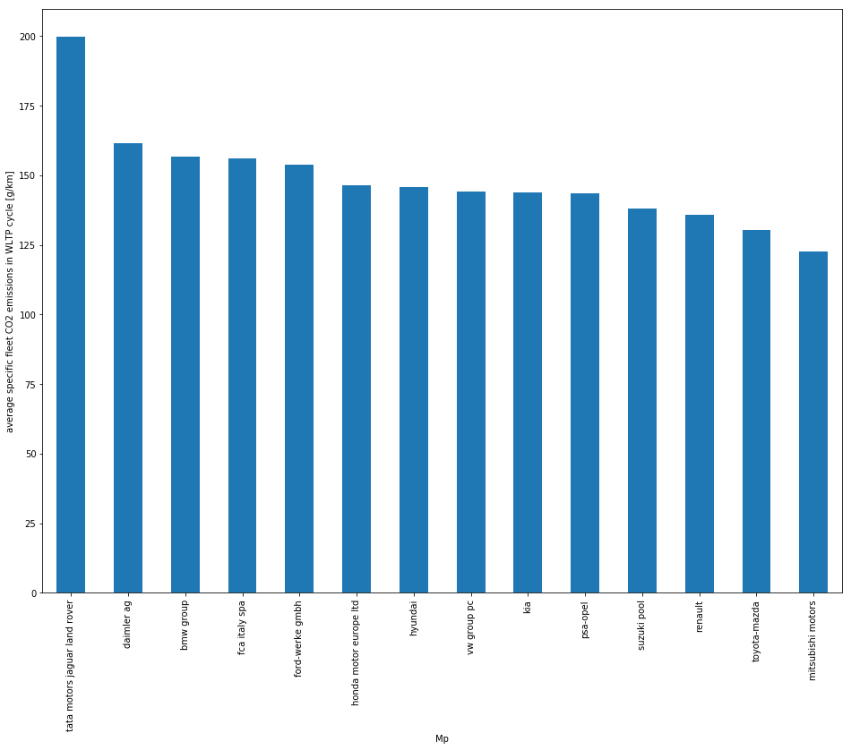

```python
plt.figure(figsize=(16, 12))
pool_fleet_emmissions['mean(Ewltp (g/km))'].sort_values(ascending = False).plot(kind = 'bar')
plt.ylabel('average specific fleet CO2 emissions in WLTP cycle [g/km]');
```

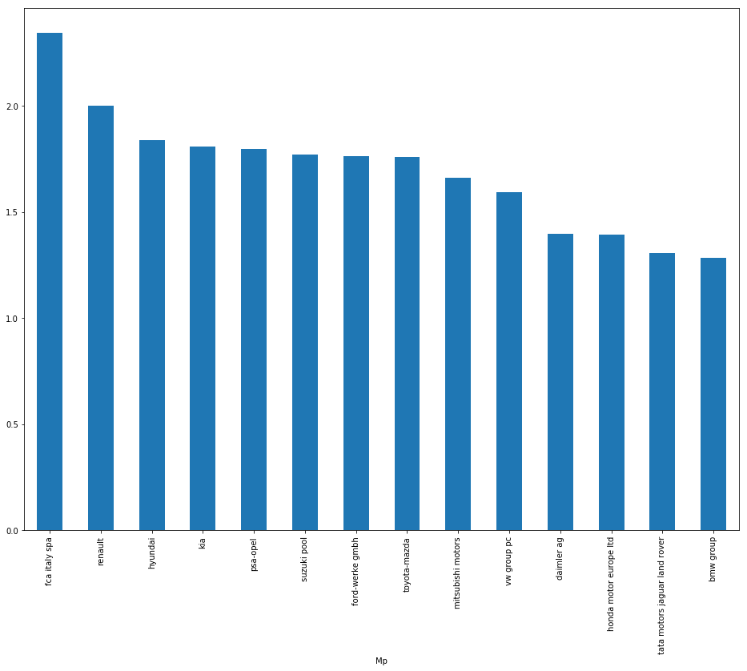

```python
plt.figure(figsize=(16, 12))
pool_fleet_emmissions['mean(RelEwltp (g/km/KW))'].sort_values(ascending = False).plot(kind = 'bar')
```

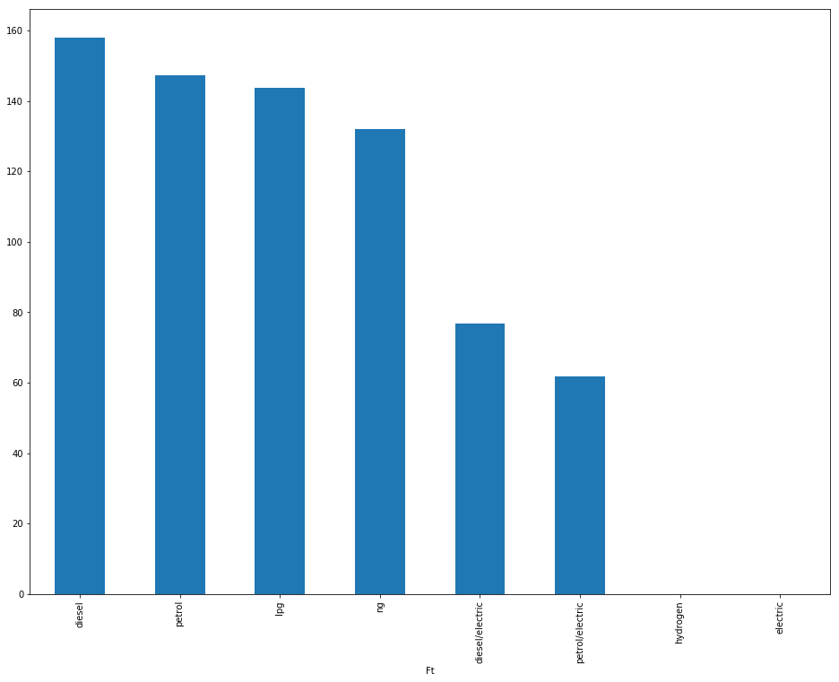

```python
plt.figure(figsize=(16, 12))
Ft_emmissions['mean(Ewltp (g/km))'].sort_values(ascending = False).plot(kind = 'bar')
```

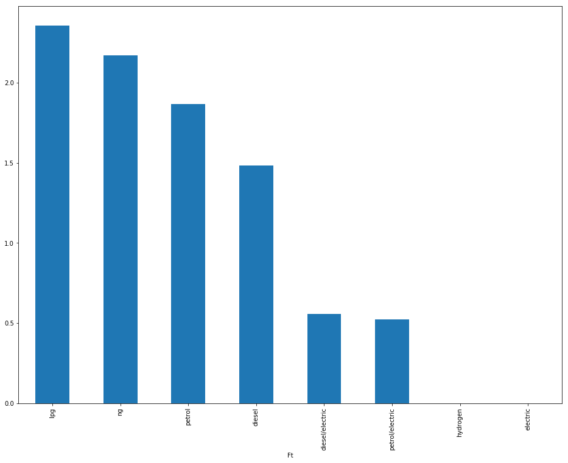

```python
plt.figure(figsize=(16, 12))
Ft_emmissions['mean(RelEwltp (g/km/KW))'].sort_values(ascending = False).plot(kind = 'bar')
```

> The following block(s) might be useful to answer question(s) like:
> - How can OEMs reduce their fleet emissions?
> - When is the best time to buy an electrified vehicle in europe?

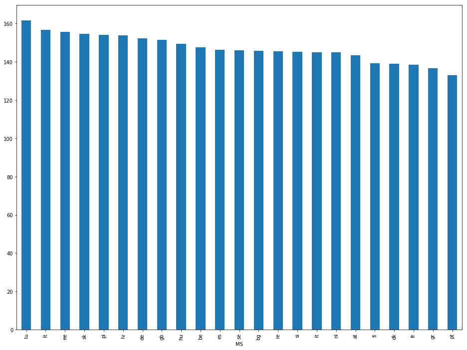

```python
plt.figure(figsize=(16, 12))
MS_emmissions['mean(Ewltp (g/km))'].sort_values(ascending = False).plot(kind = 'bar')
```

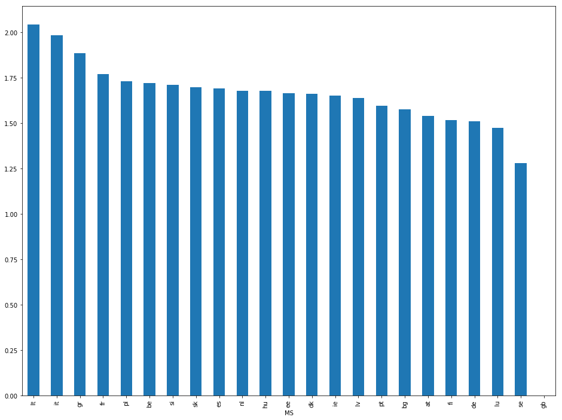

```python
plt.figure(figsize=(16, 12))
MS_emmissions['mean(RelEwltp (g/km/KW))'].sort_values(ascending = False).plot(kind = 'bar')
```

> The following block(s) might be useful to answer question(s) like:
> - Which vehicle characteristics show a significant influence on the vehicles CO2 emission?

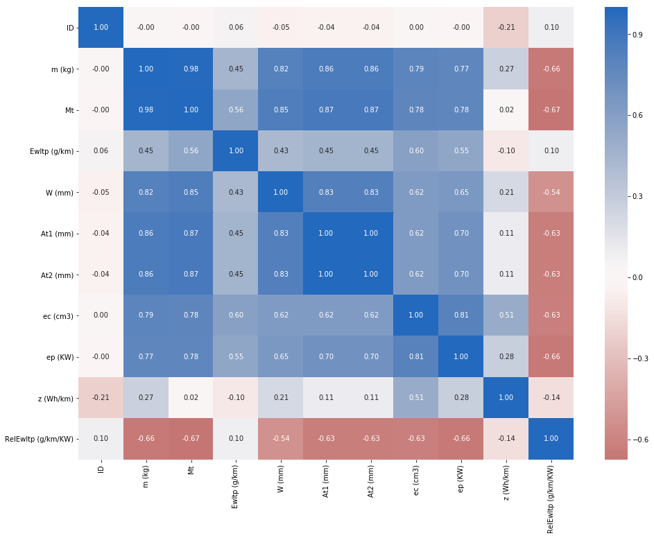

```python
#plot correlation heatmap
plt.figure(figsize=(16, 12))
sb.heatmap(df.corr(), annot = True, fmt = '.2f', cmap = 'vlag_r', center = 0)
```

> The following block(s) might be useful to answer question(s) like:
> - Which vehicle characteristics show a significant influence on the vehicles CO2 emission?
> - How can OEMs reduce their fleet emissions?
> - When is the best time to buy an electrified vehicle in europe?

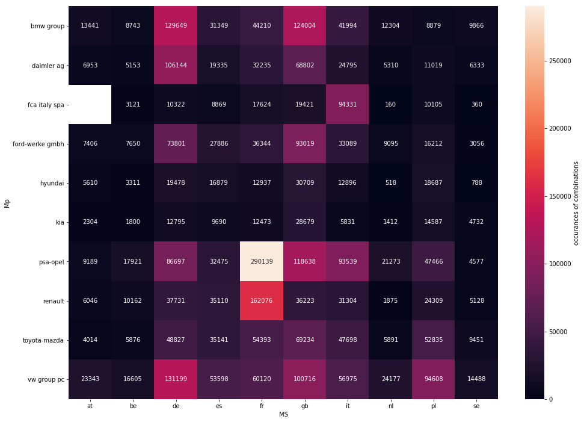

```python
# plot heat map combining countrys and OEMs
plt.figure(figsize=(16, 12))
reducedQuadrHeatMap(df, ['MS', 'Mp'], 'Ewltp (g/km)', 10, kind = 'count')
```

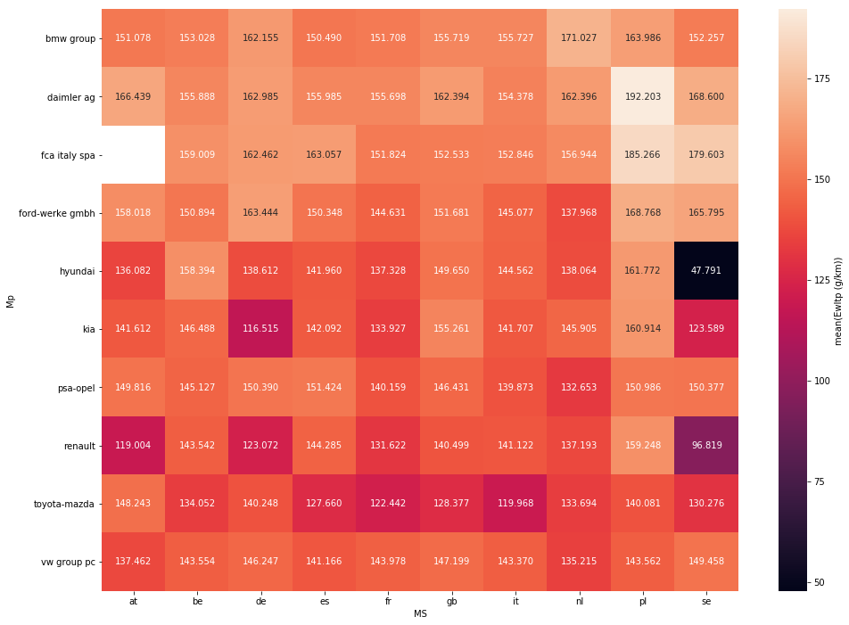

```python
# plot heat map combining countrys and OEMs
plt.figure(figsize=(16, 12))
reducedQuadrHeatMap(df, ['MS', 'Mp'], 'Ewltp (g/km)', 10, kind = 'mean')
```

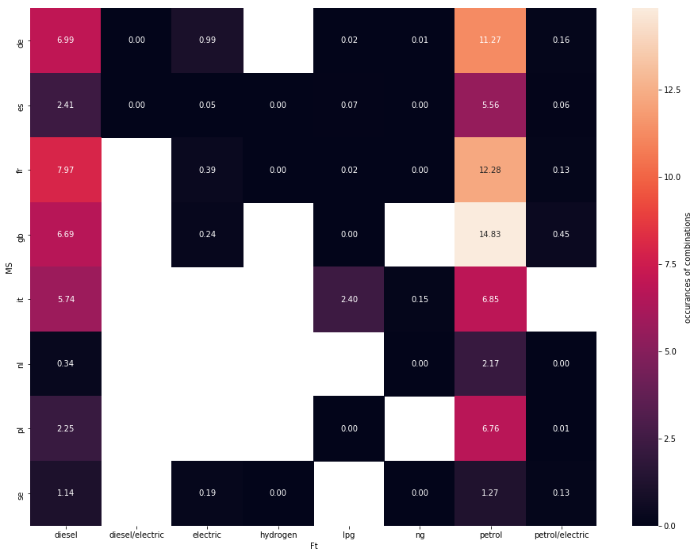

```python
# plot heat map combining countrys and OEMs
plt.figure(figsize=(16, 12))
reducedQuadrHeatMap(df, ['Ft', 'MS'], 'Ewltp (g/km)', 8, kind = 'percentage')
```

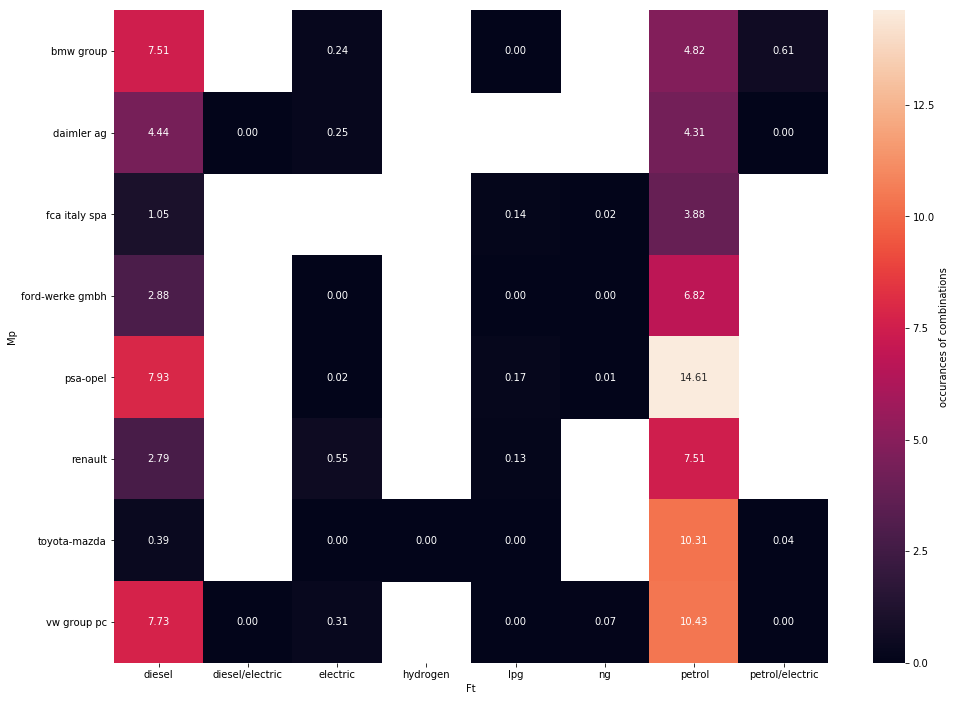

```python
# plot heat map combining countrys and OEMs
plt.figure(figsize=(16, 12))
reducedQuadrHeatMap(df, ['Ft', 'Mp'], 'Ewltp (g/km)', 8, kind = 'percentage')
```

> The following block(s) might be useful to answer question(s) like:
> - Which vehicle characteristics show a significant influence on the vehicles CO2 emission?
> - How can OEMs reduce their fleet emissions?

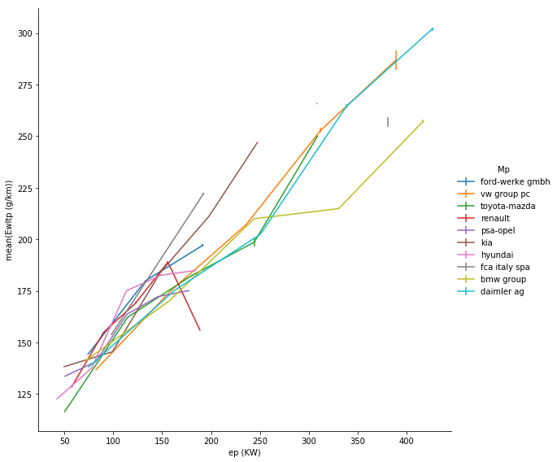

```python
# plot the CO2 emisions (WLTP test cycle) vs. engine power
plt.figure(figsize=(16, 12))
g = sb.FacetGrid(data = mostFrequentOccurencesOf(df, 'Mp', 10), hue ='Mp', height = 8)
g.map(mean_poly, 'ep (KW)', 'Ewltp (g/km)', bins = 5)
g.set_ylabels('mean(Ewltp (g/km))')
g.add_legend()
```

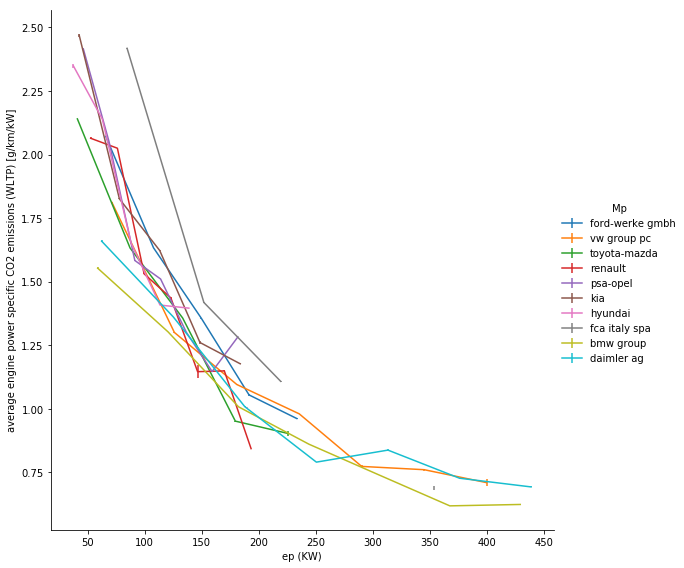

```python
# plot the power specific CO2 emisions (WLTP test cycle) vs. engine power
plt.figure(figsize=(16, 12))
g = sb.FacetGrid(data = mostFrequentOccurencesOf(df, 'Mp', 10), hue ='Mp', height = 8)
g.map(mean_poly, 'ep (KW)', 'RelEwltp (g/km/KW)', bins = 7)
g.set_ylabels('average engine power specific CO2 emissions (WLTP) [g/km/kW]')
g.add_legend()
```

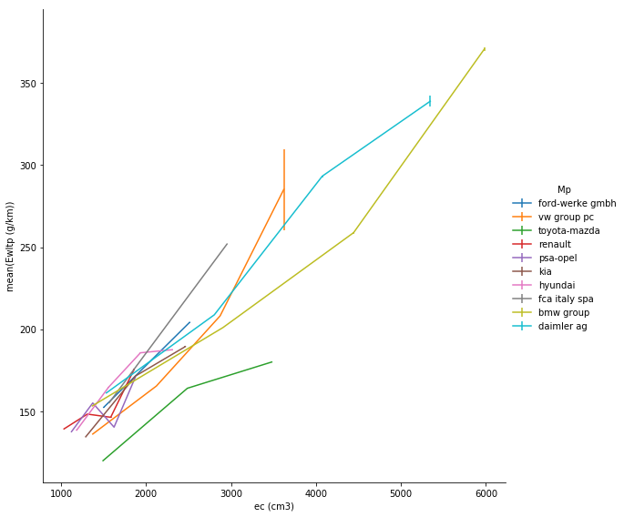

```python
# plot the CO2 emisions (WLTP test cycle) vs. engine size
plt.figure(figsize=(16, 12))
g = sb.FacetGrid(data = mostFrequentOccurencesOf(df, 'Mp', 10), hue ='Mp', height = 8)
g.map(mean_poly, 'ec (cm3)', 'Ewltp (g/km)', bins = 4)
g.set_ylabels('mean(Ewltp (g/km))')
g.add_legend()
```

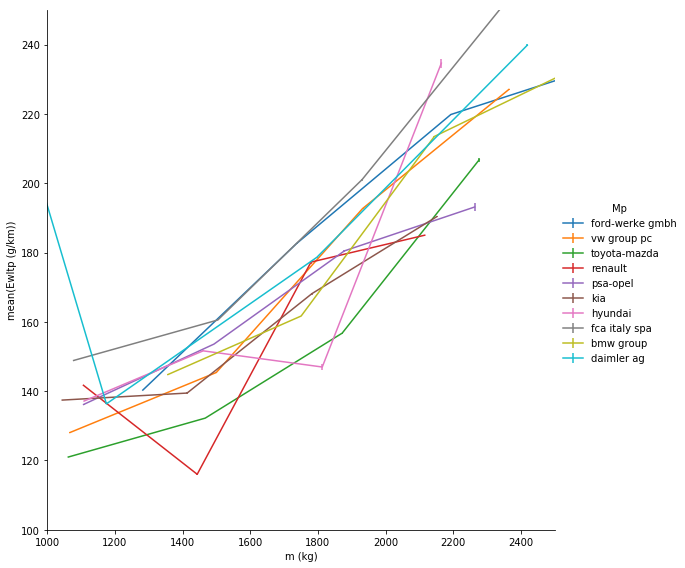

```python
# plot the CO2 emisions (WLTP test cycle) vs. vehicle mass
plt.figure(figsize=(16, 12))
g = sb.FacetGrid(data = mostFrequentOccurencesOf(df, 'Mp', 10), hue ='Mp', height = 8)
g.map(mean_poly, 'm (kg)', 'Ewltp (g/km)', bins = 4)
g.set_ylabels('mean(Ewltp (g/km))')
g.set(xlim = (1000, 2500))
g.set(ylim = (100, 250))
g.add_legend()
```

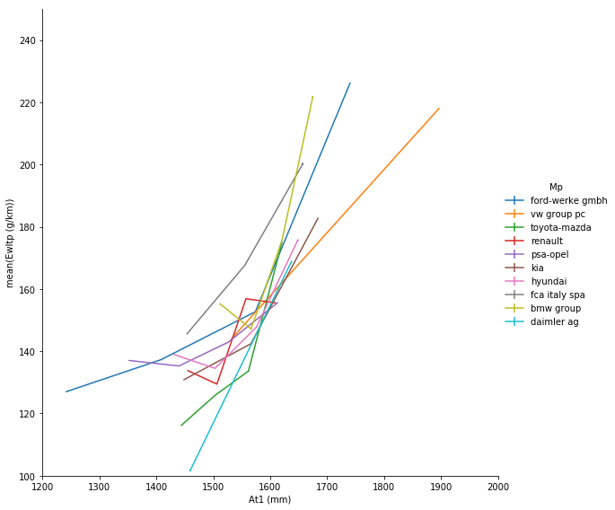

```python
# plot the CO2 emisions (WLTP test cycle) vs. axle width steering axle
plt.figure(figsize=(16, 12))
g = sb.FacetGrid(data = mostFrequentOccurencesOf(df, 'Mp', 10), hue ='Mp', height = 8)
g.map(mean_poly, 'At1 (mm)', 'Ewltp (g/km)', bins = 4)
g.set_ylabels('mean(Ewltp (g/km))')
g.set(xlim = (1200, 2000))
g.set(ylim = (100, 250))
g.add_legend()
```

## Modelling

```python
# create model to anticipate CO2 emisions
#df_model = df.drop(['ID', 'Cn', 'Fm', 'simple_Cn', 'At1 (mm)', 'At2 (mm)', 'RelEwltp (g/km/KW)'], axis=1)
#test_score, train_score, lm_model, X_train, X_test, y_train, y_test, coefCorr = clean_fit_linear_mod(df_model, 'Ewltp (g/km)', ['Ft', 'MS', 'Mp'], dummy_na = False, test_size = .3, rand_state  = 42)
```

```python
# create model to anticipate power specific CO2 emisions
df_model = df.drop(['ID', 'Cn', 'Fm', 'simple_Cn', 'At1 (mm)', 'At2 (mm)', 'Ewltp (g/km)', 'MS'], axis=1)
test_score, train_score, lm_model, X_train, X_test, y_train, y_test, coefCorr = clean_fit_linear_mod(df_model, 'RelEwltp (g/km/KW)', ['Ft', 'Mp'], dummy_na = False, test_size = .3, rand_state  = 42)
```

```python
# alternative model without categorical variables
#df_model = df.drop(['ID', 'Cn', 'Fm', 'simple_Cn', 'Enedc (g/km)','At1 (mm)', 'At2 (mm)', 'Ft', 'MS', 'Mp'], axis=1)
#test_score, train_score, lm_model, X_train, X_test, y_train, y_test, coefCorr = clean_fit_linear_mod(df_model, 'Ewltp (g/km)', [], dummy_na = False, test_size = .3, rand_state  = 42)
```

```python
X_train.head()
```

|  | m (kg) | Mt | W (mm) | ec (cm3) | ep (KW) | z (Wh/km) | Ft_diesel/electric | Ft_electric | Ft_hydrogen | Ft_lpg | Ft_ng | Ft_petrol | Ft_petrol/electric | Mp_daimler ag | Mp_fca italy spa | Mp_ford-werke gmbh | Mp_honda motor europe ltd | Mp_hyundai | Mp_kia | Mp_mitsubishi motors | Mp_psa-opel | Mp_renault | Mp_suzuki pool | Mp_tata motors jaguar land rover | Mp_toyota-mazda | Mp_vw group pc |
| --- | --- | --- | --- | --- | --- | --- | --- | --- | --- | --- | --- | --- | --- | --- | --- | --- | --- | --- | --- | --- | --- | --- | --- | --- | --- | --- |
| 4801908 | 1575.0 | 1686.0 | 2810.0 | 1995.0 | 110.0 | 162.92786 | 0 | 0 | 0 | 0 | 0 | 0 | 0 | 0 | 0 | 0 | 0 | 0 | 0 | 0 | 0 | 0 | 0 | 0 | 0 | 0 |
| 2858261 | 1801.0 | 2146.0 | 3275.0 | 1997.0 | 110.0 | 162.92786 | 0 | 0 | 0 | 0 | 0 | 0 | 0 | 0 | 0 | 0 | 0 | 0 | 0 | 0 | 1 | 0 | 0 | 0 | 0 | 0 |
| 6822235 | 934.0 | 1053.0 | 2407.0 | 999.0 | 44.0 | 162.92786 | 0 | 0 | 0 | 0 | 0 | 1 | 0 | 0 | 0 | 0 | 0 | 0 | 0 | 0 | 0 | 0 | 0 | 0 | 0 | 1 |
| 4716101 | 1150.0 | 1263.0 | 2510.0 | 1497.0 | 54.0 | 162.92786 | 0 | 0 | 0 | 0 | 0 | 1 | 0 | 0 | 0 | 0 | 0 | 0 | 0 | 0 | 0 | 0 | 0 | 0 | 1 | 0 |
| 10188063 | 1163.0 | 1298.0 | 2493.0 | 998.0 | 74.0 | 162.92786 | 0 | 0 | 0 | 0 | 0 | 1 | 0 | 0 | 0 | 1 | 0 | 0 | 0 | 0 | 0 | 0 | 0 | 0 | 0 | 0 |

```python
test_score
```

```
0.7881955489954291
```

```python
train_score
```

```
0.7884977480329205
```

```python
lm_model.coef_
```

```
array([ 5.14111342e-05, -1.54873967e-04, -2.64859630e-04,  2.46628820e-04,
       -8.31168397e-03,  5.69599964e-03, -7.98633035e-01, -1.72891285e+00,
       -1.59082905e+00,  5.04176820e-01,  3.42552106e-01,  2.22316069e-01,
       -6.02924426e-01,  1.27181706e-02,  3.90735959e-01,  6.59123812e-02,
       -2.13945880e-01,  7.13627005e-02,  2.34395054e-02, -6.80940629e-02,
        2.38717812e-02,  2.08303268e-01, -1.56243702e-01,  2.38303444e-01,
       -2.21753825e-01, -3.49689909e-02])
```

> The following block(s) might be useful to answer question(s) like:
> - Which vehicle characteristics show a significant influence on the vehicles CO2 emission?
> - How can OEMs reduce their fleet emissions?

```python
coefCorr
```

```
[('Ft_electric', -1.7289128488488905),
 ('Ft_hydrogen', -1.5908290523294404),
 ('Ft_diesel/electric', -0.7986330349502401),
 ('Ft_petrol/electric', -0.6029244258561667),
 ('Mp_toyota-mazda', -0.22175382512059919),
 ('Mp_honda motor europe ltd', -0.2139458803047366),
 ('Mp_suzuki pool', -0.15624370179220087),
 ('Mp_mitsubishi motors', -0.06809406286251697),
 ('Mp_vw group pc', -0.03496899094216949),
 ('ep (KW)', -0.00831168396529116),
 ('W (mm)', -0.00026485962982102963),
 ('Mt', -0.00015487396702365517),
 ('m (kg)', 5.141113423299426e-05),
 ('ec (cm3)', 0.0002466288198631345),
 ('z (Wh/km)', 0.005695999639276864),
 ('Mp_daimler ag', 0.012718170566361727),
 ('Mp_kia', 0.02343950536660231),
 ('Mp_psa-opel', 0.023871781171796735),
 ('Mp_ford-werke gmbh', 0.06591238115049239),
 ('Mp_hyundai', 0.07136270047260337),
 ('Mp_renault', 0.2083032679800798),
 ('Ft_petrol', 0.22231606877761853),
 ('Mp_tata motors jaguar land rover', 0.2383034444356756),
 ('Ft_ng', 0.34255210629268),
 ('Mp_fca italy spa', 0.39073595898402663),
 ('Ft_lpg', 0.5041768202060958)]
```